# Project Milestone 3: Preliminary progress report

**NOTE**

This progress report represents the *minimum* progress you need to make in order to stay on track. You’re encouraged to do more, if possible. For example:

- Though your responses to *this* progress report can be informal, take some time to:
  - Edit written responses as they might appear in your final report.
  - Edit code and plots as they might appear in your final report (eg: use figure captions, alt text, color-blind friendly palettes, etc).
- Make more plots! Do more wrangling! Learn new things!

# Names

Put the full names (first and last) of every group member here. -Gaby Moreno Romero -Kampe Rushoka -Val Tlahuice

# 1. Background

In this section, specify:

- The overarching **research question** for your project. You will break this down into smaller pieces in your analysis, but should have a general guiding question.
- Specify your data sources, including *where* you found your dataset(s) and who *originally* collected the data. If possible, also identify the original purpose for this data collection.

Put your work below:

RQ: How have demographics (Sex, Race) and education levels affected Americans wages over time?

Data source: The Wages by Education dataset was found from Kaggle and provides provides hourly wages by the highest level of education attained for wage and salary workers aged 16 and older in the USA and disagregated for other demographic factors such as sex (Male and Female) and ethnicities(White, Black, and Hispanic). The data is adjusted into 2022 dollars using the CPI-U-RS index, to acount for inflation. It covers the years from 1973 to 2022 and is sourced from the Economic Policy Institute’s State of Working America Data Library. It is important to note some demographics such as asian, indigenous, non-binary and trans identities are missing.

# 2. Preliminary data checks and cleaning

In this section:

- Import your dataset(s).
- Do a preliminary data check. For *example*, identify:
  - units of observation
  - how many data points you have
  - the number of variables and types of things that were measured
- Do any preliminary data cleaning that’s necessary to start your analysis. For example:
  - define / clean the variables you plan to use in your analysis
  - obtain some simple summaries of the variables you plan to use in your analysis
  - as necessary:
    - reshape the data
    - join datasets

Put your work below:

Preliminary Data: - Units of observation: Aggregated demographic-year wages within the U.S.

- Number of data points: 4,500 entries (each representing a unique demographic-year combination).
- Variables measured: Demographic information: Categories such as race (Black, White), education level (less than high school), gender (women), and all possible combinations, Year: The year in which the wage data was measured, Wages: Hourly wages adjusted to 2022 dollars.

Preliminary data cleaning and refinement: We defined and cleaned the variables to ensure consistency for analysis. We also combined both median and average wage data from the Economic Policy Institute. This helps reduce the influence of extreme values, as averages can be skewed by very high or very low wages. Lastly we pivoted the data to a longer format to capture all demographic-year combinations efficiently. The dataset spans 1973–2022, with wages ranging from $10.74 to $64.04 per hour.

```r
library(readr)
library(dplyr)
library(tidyverse)


#demographic_data <- read_csv("~/Documents/DS 112/Projects/wages_by_education.csv")

demographic_data <- read_csv("wages_by_education.csv")

#median_wage <- read_csv("~/Documents/DS 112/Projects/median_average_wages 3.csv")

median_wage <- read_csv("median_average_wages 3.csv")


Combined_data <- left_join(median_wage,demographic_data, by = "year") %>%
  arrange(year)

head(Combined_data, 3)
## # A tibble: 3 × 91
##    year median average men_median men_average women_median women_average
##   <dbl>  <dbl>   <dbl>      <dbl>       <dbl>        <dbl>         <dbl>
## 1  1973   19.8    23.0       24          27.0         15.1          17.3
## 2  1974   19.4    22.6       23.7        26.5         14.9          17.0
## 3  1975   19.4    22.6       24.1        26.5         15.1          17.2
## # ℹ 84 more variables: white_median <dbl>, white_average <dbl>,
## #   black_median <dbl>, black_average <dbl>, hispanic_median <dbl>,
## #   hispanic_average <dbl>, white_men_median <dbl>, white_men_average <dbl>,
## #   black_men_median <dbl>, black_men_average <dbl>, hispanic_men_median <dbl>,
## #   hispanic_men_average <dbl>, white_women_median <dbl>,
## #   white_women_average <dbl>, black_women_median <dbl>,
## #   black_women_average <dbl>, hispanic_women_median <dbl>, …


#Cleaned data with: Full Pivot longer of all demographic indicators
cleaned_data_1 <- Combined_data %>%
  pivot_longer(cols = -year , names_to = "demographic", values_to = "Wages")

head(cleaned_data_1, 15)
## # A tibble: 15 × 3
##     year demographic       Wages
##    <dbl> <chr>             <dbl>
##  1  1973 median             19.8
##  2  1973 average            23.0
##  3  1973 men_median         24
##  4  1973 men_average        27.0
##  5  1973 women_median       15.1
##  6  1973 women_average      17.3
##  7  1973 white_median       20.5
##  8  1973 white_average      23.7
##  9  1973 black_median       16.0
## 10  1973 black_average      18.6
## 11  1973 hispanic_median    16.4
## 12  1973 hispanic_average   18.7
## 13  1973 white_men_median   25.0
## 14  1973 white_men_average  27.9
## 15  1973 black_men_median   19.3
nrow(cleaned_data_1)
## [1] 4500
summary(cleaned_data_1)
##       year      demographic            Wages
##  Min.   :1973   Length:4500        Min.   :10.74
##  1st Qu.:1985   Class :character   1st Qu.:17.64
##  Median :1998   Mode  :character   Median :21.66
##  Mean   :1998                      Mean   :24.41
##  3rd Qu.:2010                      3rd Qu.:29.00
##  Max.   :2022                      Max.   :64.04
##                                    NA's   :96
```

```r
# gender wage ratio by demographics group

cleaned_data_6 <- Combined_data %>%
  mutate(wage_ratio_overall= women_median/men_median,
         wage_ratio_white= white_women_median/ white_men_median,
         wage_ratio_black=  black_women_median/ black_men_median,
         wage_ratio_hispanic= hispanic_women_median/ hispanic_men_median) %>%
  select(year,wage_ratio_overall, wage_ratio_white, wage_ratio_black, wage_ratio_hispanic)
cleaned_data_6 %>%
  select(year,wage_ratio_overall, wage_ratio_white, wage_ratio_black, wage_ratio_hispanic)
## # A tibble: 50 × 5
##     year wage_ratio_overall wage_ratio_white wage_ratio_black
##    <dbl>              <dbl>            <dbl>            <dbl>
##  1  1973              0.629            0.615            0.694
##  2  1974              0.628            0.620            0.708
##  3  1975              0.626            0.621            0.700
##  4  1976              0.642            0.634            0.728
##  5  1977              0.632            0.615            0.752
##  6  1978              0.625            0.614            0.709
##  7  1979              0.634            0.606            0.755
##  8  1980              0.637            0.614            0.755
##  9  1981              0.654            0.626            0.760
## 10  1982              0.646            0.628            0.792
## # ℹ 40 more rows
## # ℹ 1 more variable: wage_ratio_hispanic <dbl>
```

# 3. Preliminary analysis (OPTIONAL)

In this section, you are encouraged to build and perhaps discuss some plots *and* numerical summaries that address your research question(s). Though this section technically isn’t required, any extra analysis you do now will support and simplify your future work.

Put your work below: Preliminary Analysis of Wage Trends

Education Level Differences: The education-level graph shows a strong and consistent pattern: higher education is associated with higher wages. The wage hierarchy follows the expected order:Advanced degree holders earn the highest wages, Bachelor’s degree holders follow, Some college, high school, and less than high school form a lower cluster with wages in a relatively similar and lower range.

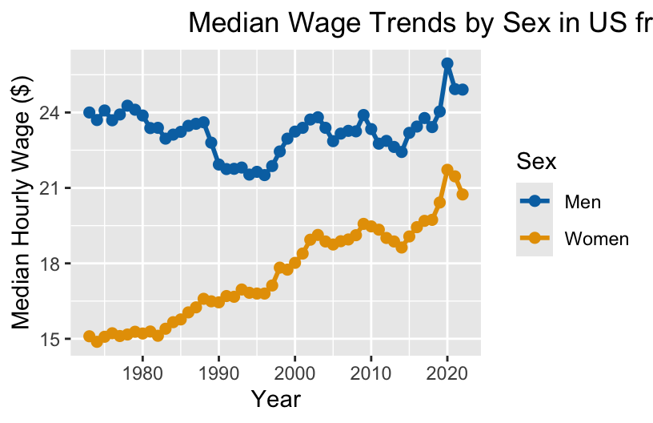

Scatterplot of median hourly wages ($) by sex over time. The graph shows that since 1973 till 2022, men (blue line) have consistently had higher median wages than women (orange line). However, the wage gap has gradually decreased over the years.

```r
#Gender
cleaned_data_3 <- Combined_data %>%
  select(men_median, women_median, year) %>%
  pivot_longer(cols = -year , names_to = "demographic", values_to = "Wages") %>%
  mutate(demographic= recode(demographic,
                             "men_median" = "Men",
                             "women_median" = "Women"))

ggplot(cleaned_data_3, aes(x = year, y = Wages, color = demographic)) +
  scale_color_manual(values = c("Men" = "#0072B2", "Women" = "#E69F00")) +
  geom_point(size = 2) +
  geom_line(size = 1)+
    labs(title = "               Median Wage Trends by Sex in US from 1973 to 2022",
         x = "Year",
         y = "Median Hourly Wage ($)",
         color  = "Sex")
```

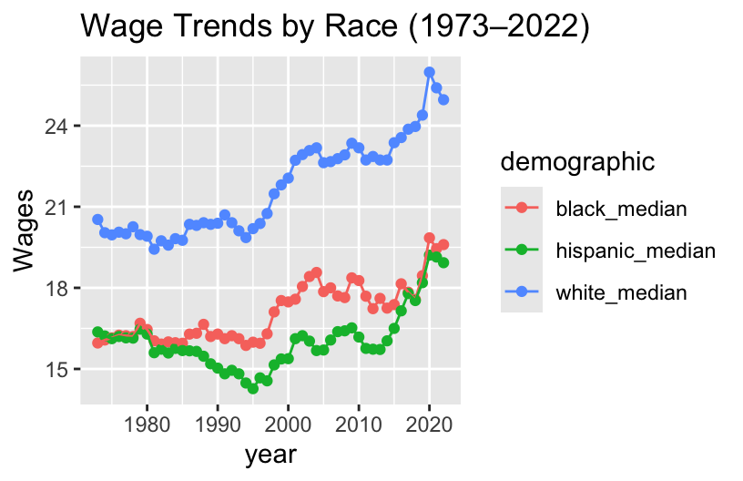

```r
#Race
cleaned_data_4 <- Combined_data %>%
  select(white_median, black_median, hispanic_median, year) %>%
  pivot_longer(cols = -year , names_to = "demographic", values_to = "Wages")

ggplot(cleaned_data_4, aes(x = year, y = Wages, color = demographic)) +
  geom_point() +
  geom_line() +
    labs(title = "Wage Trends by Race (1973–2022)")
```

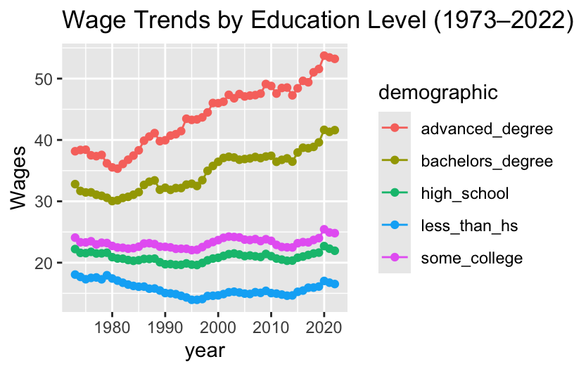

```r
#Education:

cleaned_data_5 <- Combined_data %>%
  select(less_than_hs, high_school, some_college, bachelors_degree, advanced_degree, year) %>%
  pivot_longer(cols = -year , names_to = "demographic", values_to = "Wages")

ggplot(cleaned_data_5, aes(x = year, y = Wages, color = demographic)) +
  geom_point() +
  geom_line() +
  labs(title = "Wage Trends by Education Level (1973–2022)")
```

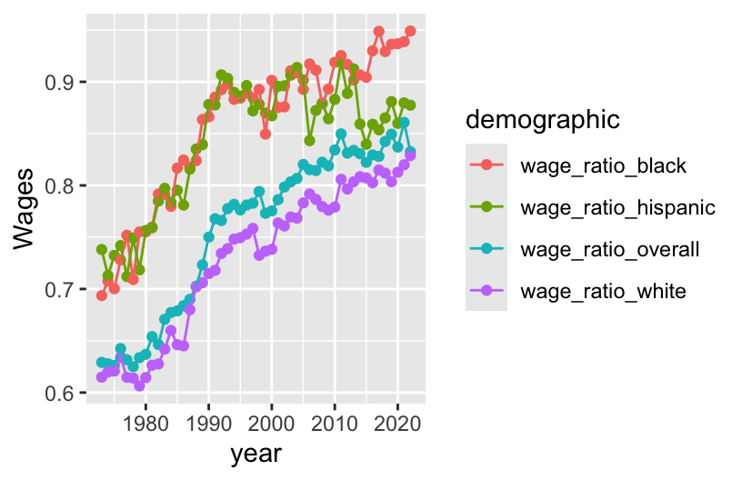

```r
# gender wage ratio by race:

cleaned_data_6 %>%
 pivot_longer(cols = -year , names_to = "demographic", values_to = "Wages") %>%

ggplot(aes(x = year, y = Wages, color = demographic)) +
  geom_point() +
  geom_line()
```

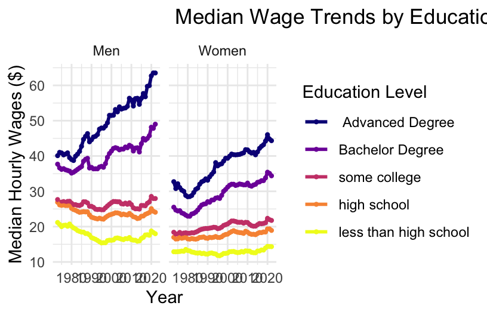

This graph displays a scatterplot of median hourly wages from the EPI by educational attainment for men and women over time. The plot shows that, for both sexes, higher educational attainment is consistently associated with higher median wages. However, when comparing the same education levels, men’s median wages remain higher than women’s.

```r
#Education & Gender

#I could categorize them in High levels and low levels of education, and make those variables,
#I could also categorize them in Gender, Male or Female
#Then when I pivot longer, I could have gender, level of education and wage.


cleaned_data_2 <- cleaned_data_1 %>%
  mutate(Gender = case_when(
    str_starts(demographic, "men_") ~ "Men",
    str_starts(demographic,"women_") ~ "Women",
    TRUE ~ NA_character_
  )) %>%
  mutate(Education_level = case_when(
    str_detect(demographic, c("less_than_hs")) ~ "less_than_hs",
    str_detect(demographic, c("high_school")) ~ "high school",
    str_detect(demographic, c("some_college")) ~ "some college",
    str_detect(demographic, c("bachelors_degree")) ~ "Bachelor",
    str_detect(demographic, c("advanced_degree")) ~ "Advanced",
    TRUE ~ NA_character_
  )) %>%
  mutate(Education_level = fct_relevel(Education_level, c("Advanced","Bachelor","some college", "high school","less_than_hs"))) %>%
  mutate(Education_level = recode(Education_level,
                                  "Advanced" = " Advanced Degree",
                                  "Bachelor" = "Bachelor Degree",
                                  "less_than_hs" = "less than high school")) %>%
  drop_na(Gender, Education_level)


cleaned_data_2
## # A tibble: 500 × 5
##     year demographic            Wages Gender Education_level
##    <dbl> <chr>                  <dbl> <chr>  <fct>
##  1  1973 men_less_than_hs        21.2 Men    "less than high school"
##  2  1973 men_high_school         26.9 Men    "high school"
##  3  1973 men_some_college        27.7 Men    "some college"
##  4  1973 men_bachelors_degree    37.7 Men    "Bachelor Degree"
##  5  1973 men_advanced_degree     40.1 Men    " Advanced Degree"
##  6  1973 women_less_than_hs      12.9 Women  "less than high school"
##  7  1973 women_high_school       17.0 Women  "high school"
##  8  1973 women_some_college      18.4 Women  "some college"
##  9  1973 women_bachelors_degree  25.5 Women  "Bachelor Degree"
## 10  1973 women_advanced_degree   32.7 Women  " Advanced Degree"
## # ℹ 490 more rows

#Drawing a Visualisation:
ggplot(cleaned_data_2, aes(x=year, y = Wages, color = Education_level))+
  geom_point(size = 0.8) +
  scale_color_viridis_d(option = "C") +
  geom_line(size = 1) +
  facet_wrap(~Gender)+
  labs(
    title = "                     Median Wage Trends by Education Level and Sex (1973-2020)",
    x = "Year",
    y = "Median Hourly Wages ($)",
    color = "Education Level"
  )+
  theme_minimal()
```

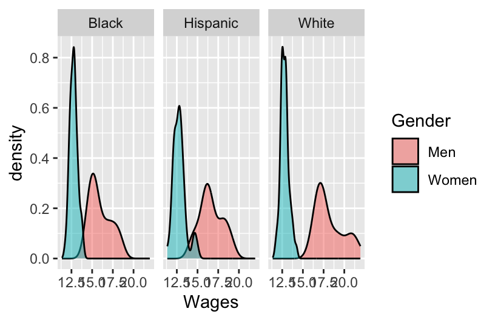

```r
# Density plot of different education levels:
#Less than High school
less_hs_data <- cleaned_data_1 %>%
  filter(str_ends(demographic,"less_than_hs")) %>%
  mutate(
    Race = case_when(
      str_starts(demographic, "white") ~ "White",
      str_starts(demographic, "black") ~ "Black",
      str_starts(demographic, "hispanic") ~ "Hispanic",
      TRUE ~ "NA"
    )) %>%
  mutate(
    Gender = case_when(
      str_detect(demographic, "_men_") ~ "Men",
      str_detect(demographic, "_women_") ~ "Women",
      TRUE ~ "NA"
    )) %>%
  filter(Race != "NA", Gender != "NA")

less_hs_data
## # A tibble: 300 × 5
##     year demographic                 Wages Race     Gender
##    <dbl> <chr>                       <dbl> <chr>    <chr>
##  1  1973 white_men_less_than_hs       22.0 White    Men
##  2  1973 black_men_less_than_hs       18.6 Black    Men
##  3  1973 hispanic_men_less_than_hs    18.4 Hispanic Men
##  4  1973 white_women_less_than_hs     13.1 White    Women
##  5  1973 black_women_less_than_hs     12.0 Black    Women
##  6  1973 hispanic_women_less_than_hs  12.9 Hispanic Women
##  7  1974 white_men_less_than_hs       21.3 White    Men
##  8  1974 black_men_less_than_hs       18.2 Black    Men
##  9  1974 hispanic_men_less_than_hs    19.3 Hispanic Men
## 10  1974 white_women_less_than_hs     13.0 White    Women
## # ℹ 290 more rows

ggplot(less_hs_data, aes(x = Wages, fill = Gender)) +
  geom_density(alpha = 0.5) +
  facet_wrap(~Race)
```

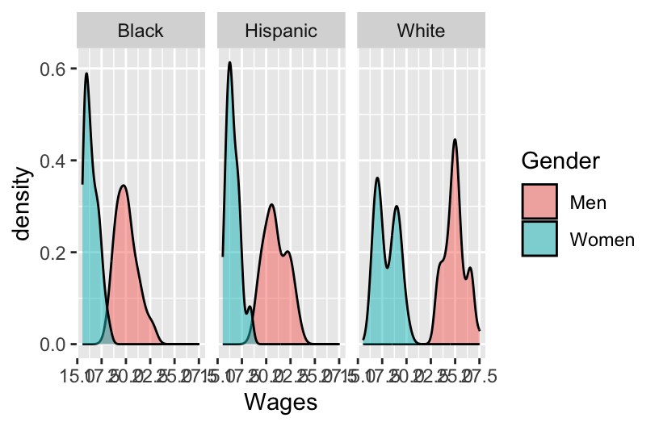

```r
# High school
hs <-  cleaned_data_1 %>%
  filter(str_ends(demographic,"high_school")) %>%
  mutate(
    Race = case_when(
      str_starts(demographic, "white") ~ "White",
      str_starts(demographic, "black") ~ "Black",
      str_starts(demographic, "hispanic") ~ "Hispanic",
      TRUE ~ "NA"
    )) %>%
  mutate(
    Gender = case_when(
      str_detect(demographic, "_men_") ~ "Men",
      str_detect(demographic, "_women_") ~ "Women",
      TRUE ~ "NA"
    )) %>%
  filter(Race != "NA", Gender != "NA")



ggplot(hs, aes(x = Wages, fill = Gender)) +
  geom_density(alpha = 0.5) +
  facet_wrap(~Race)
```

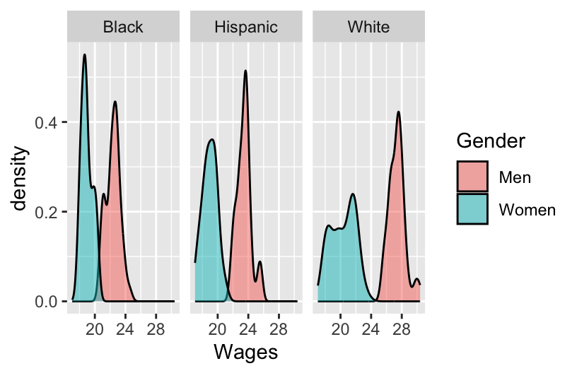

```r
# Some College
some_college_data <-  cleaned_data_1 %>%
  filter(str_ends(demographic,"some_college")) %>%
  mutate(
    Race = case_when(
      str_starts(demographic, "white") ~ "White",
      str_starts(demographic, "black") ~ "Black",
      str_starts(demographic, "hispanic") ~ "Hispanic",
      TRUE ~ "NA"
    )) %>%
  mutate(
    Gender = case_when(
      str_detect(demographic, "_men_") ~ "Men",
      str_detect(demographic, "_women_") ~ "Women",
      TRUE ~ "NA"
    )) %>%
  filter(Race != "NA", Gender != "NA")



ggplot(some_college_data, aes(x = Wages, fill = Gender)) +
  geom_density(alpha = 0.5) +
  facet_wrap(~Race)
```

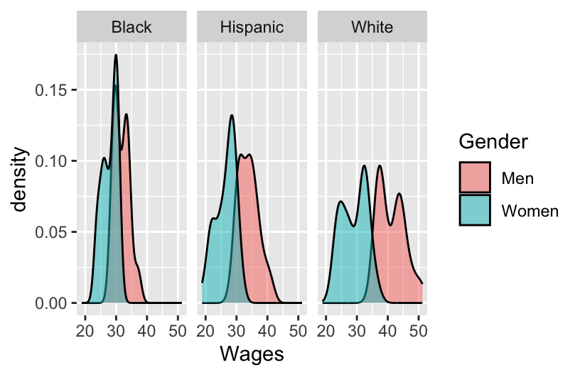

```r
# Bachelors degree
bachelor_data <-  cleaned_data_1 %>%
  filter(str_ends(demographic,"bachelors_degree")) %>%
  mutate(
    Race = case_when(
      str_starts(demographic, "white") ~ "White",
      str_starts(demographic, "black") ~ "Black",
      str_starts(demographic, "hispanic") ~ "Hispanic",
      TRUE ~ "NA"
    )) %>%
  mutate(
    Gender = case_when(
      str_detect(demographic, "_men_") ~ "Men",
      str_detect(demographic, "_women_") ~ "Women",
      TRUE ~ "NA"
    )) %>%
  filter(Race != "NA", Gender != "NA")



ggplot(bachelor_data, aes(x = Wages, fill = Gender)) +
  geom_density(alpha = 0.5) +
  facet_wrap(~Race)
```

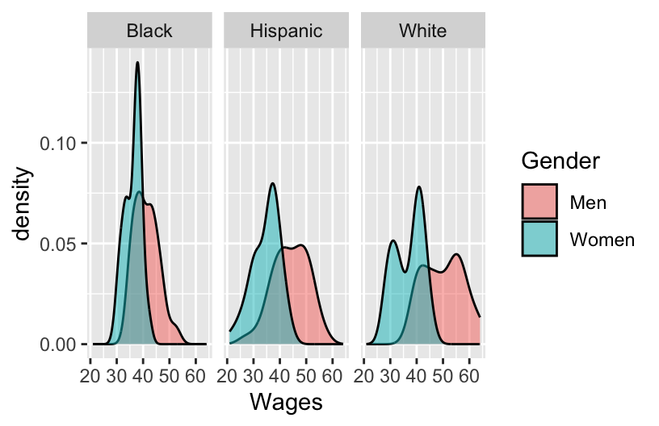

```r
#Advanced degree:
advanced_data <-  cleaned_data_1 %>%
  filter(str_ends(demographic,"advanced_degree")) %>%
  mutate(
    Race = case_when(
      str_starts(demographic, "white") ~ "White",
      str_starts(demographic, "black") ~ "Black",
      str_starts(demographic, "hispanic") ~ "Hispanic",
      TRUE ~ "NA"
    )) %>%
  mutate(
    Gender = case_when(
      str_detect(demographic, "_men_") ~ "Men",
      str_detect(demographic, "_women_") ~ "Women",
      TRUE ~ "NA"
    )) %>%
  filter(Race != "NA", Gender != "NA")



ggplot(advanced_data, aes(x = Wages, fill = Gender)) +
  geom_density(alpha = 0.5) +
  facet_wrap(~Race)
```

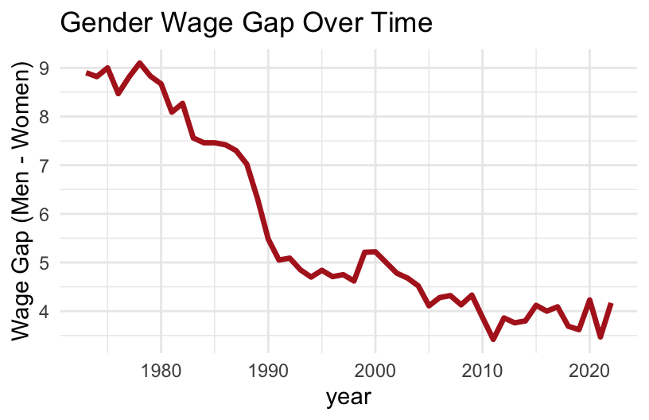

```r
gap_data <- Combined_data %>%
  mutate(gender_gap = men_median - women_median)

ggplot(gap_data, aes(x = year, y = gender_gap)) +
  geom_line(color = "firebrick", size = 1.2) +
  theme_minimal() +
  labs(title = "Gender Wage Gap Over Time",
       y = "Wage Gap (Men - Women)")
```

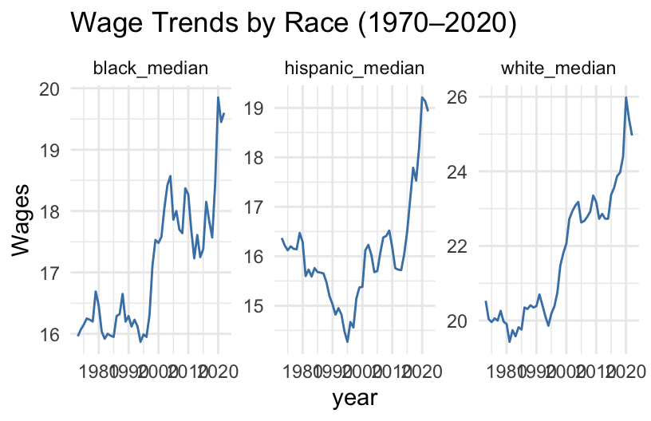

```r
ggplot(cleaned_data_4, aes(x = year, y = Wages)) +
  geom_line(color = "steelblue") +
  facet_wrap(~ demographic, scales = "free_y") +
  theme_minimal() +
  labs(title = "Wage Trends by Race (1970–2020)")
```

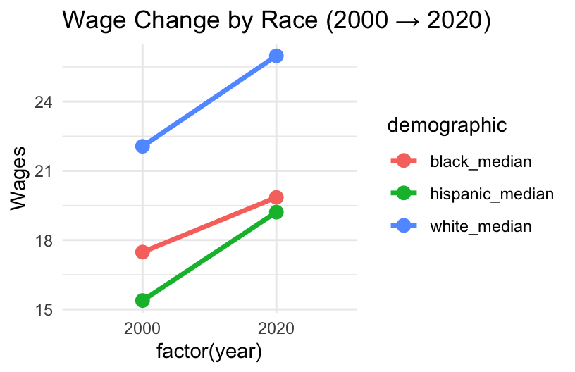

```r
slope_data <- Combined_data %>%
  filter(year %in% c(2000, 2020)) %>%
  select(year, white_median, black_median, hispanic_median) %>%
  pivot_longer(cols = -year, names_to = "demographic", values_to = "Wages")

ggplot(slope_data, aes(x = factor(year), y = Wages, group = demographic, color = demographic)) +
  geom_line(size = 1.2) +
  geom_point(size = 3) +
  theme_minimal() +
  labs(title = "Wage Change by Race (2000 → 2020)")
```

# 4. Vision

Remember that growth and depth are key components of the final project assessment. Identify here what types of tools / skills do you plan to learn throughout the course of this project (or perhaps even what new things you already learned)! Revisit the project overview for ideas.

Put your work below:

One major area of improvement is learning how to reshape datasets. Specifically, understanding how to use pivot longer/ wider and joints more confidently, since those have been some of the trickiest parts of the course for me. Also, we can improve my interpretation of wage trends by connecting statistical patterns to broader social and economic contexts in the United States. For this, it is important to also improve how to create clear and comparative visualization, especially when we have plots that show differences across sex, race, and education levels at the same time. Finally, we want to be mindful about missing groups (such as Asian, Indigenous, non-binary) when interpreting results. As we continue, we want to strengthen both the technical R skills and the critical reasoning needed to analyze wage inequality over time.

```r
#One number summary:
one_number_summary <- cleaned_data_1 %>%
  mutate(
    Race = case_when(
      str_starts(demographic, "white") ~ "White",
      str_starts(demographic, "black") ~ "Black",
      str_starts(demographic, "hispanic") ~ "Hispanic",
      TRUE ~ "NA"
    )) %>%
  mutate(
    Gender = case_when(
      str_detect(demographic, "_men_") ~ "Men",
      str_detect(demographic, "_women_") ~ "Women",
      TRUE ~ "NA"
    )) %>%
  filter(Race != "NA", Gender != "NA")

one_number_summary %>%
  group_by(Gender) %>%
  summarise(range(Wages))
## # A tibble: 4 × 2
## # Groups:   Gender [2]
##   Gender `range(Wages)`
##   <chr>           <dbl>
## 1 Men              14.1
## 2 Men              64.0
## 3 Women            11.4
## 4 Women            45.6
```

# 5. Reflection form

Only after you’ve completed items 1–4 above, each individual group member must fill out this [reflection form](https://forms.gle/xCtgxM2fxYjcCJvn6).

Missing ethnicities(Asian Americans, Asians, Indigenous communities) and gender(Non-binary, trans…)

# Wrapping up

- Render your qmd to html, check/fix the formatting, then submit the html!
- Remember that this progress report represents the *minimum* progress you need to make in order to stay on track. You’re encouraged to do more, if possible. Ideas are outlined at the top of this assignment.